# SHARP Multiomics Workshop: Data Description

Pre-Workshop Lab

David Conti

17 May 2025

## Data Overview

This describes the data that will be used for many of the labs throughout the workshop. We also present an example on how to construct a MultiAssayExperiment object - an R object for storing multi-view or multiple omic data sets measured on the same individuals.

## Exposome Data Challenge

[figure not shown]

The data is from the Exposome Data Analysis Challenge (https://www.isglobal.org/-/exposome-data-analysis-challenge). The Exposome dataset represents a real case scenario of an exposome dataset (based on the HELIX project database) with multiple correlated variables (N>100 exposure variables) arising from general and personal environments at different time points, biological molecular data (multi-omics: DNA methylation, gene expression, proteins, metabolomics, exposome) and multiple clinical phenotypes. The population is drawn from a multi-center study which will results in one of the main confounding structures in the dataset.

In addition, for the SHARP Multiomics Workshop, we simulated a germline genetics example dataset.

## The HELIX study

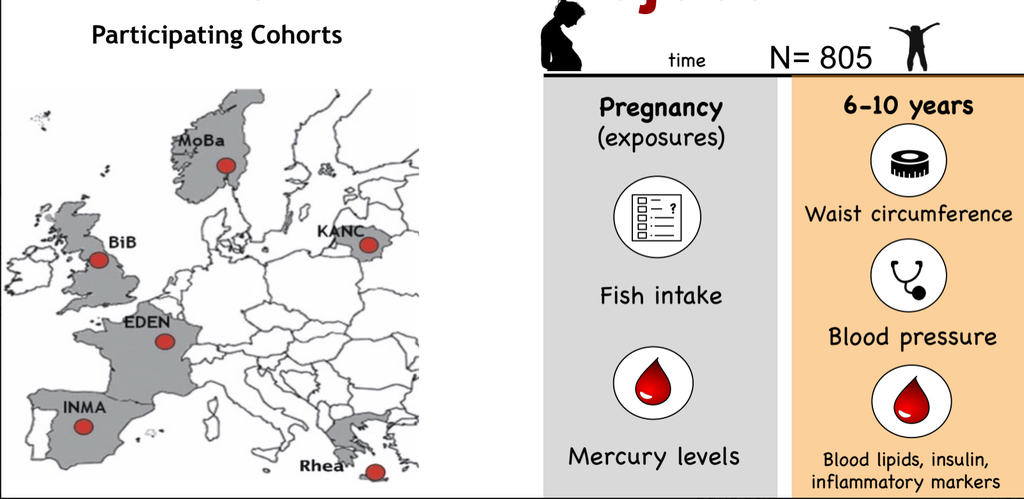

The HELIX study represents a collaborative project across six established and ongoing longitudinal population-based birth cohort studies in six European countries (France, Greece, Lithuania, Norway, Spain, and the United Kingdom). HELIX used a multilevel study design with the entire study population totaling 31,472 mother–child pairs, recruited during pregnancy, in the six existing cohorts (first level); a subcohort of 1301 mother-child pairs where biomarkers, omics signatures and child health outcomes were measured at age 6-11 years (second level); and repeat-sampling panel studies with around 150 children and 150 pregnant women aimed at collecting personal exposure data (third level). For more details on the study design see Vrijheid, Slama, et al. EHP 2014. see https://www.projecthelix.eu/index.php/es/data-inventory for more information regarding the study.

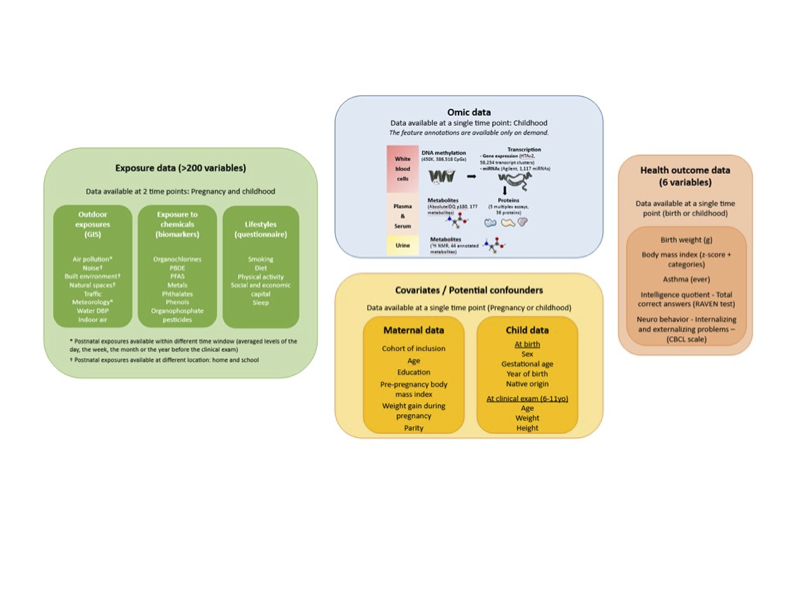

## Data Processing and Organization

```r
# Load data
load(paste0(work.dir, "/Data/exposome.RData"))
load(paste0(work.dir, "/Data/proteome.RData"))
load(paste0(work.dir, "/Data/genome.RData"))
load(paste0(work.dir, "/Data/metabol_serum.RData"))
load(paste0(work.dir, "/Data/metabol_urine.RData"))

outdoor.exposures <- exposome[,c("ID", as.character(codebook$variable_name[codebook$domain=="Outdoor exposures"]))] %>%
  column_to_rownames("ID") %>%
  t() %>% DataFrame()
indoor.air <- exposome[,c("ID", as.character(codebook$variable_name[codebook$domain=="Indoor air"]))] %>%
  column_to_rownames("ID") %>%
  t() %>% DataFrame()
lifestyles <- exposome[,c("ID", as.character(codebook$variable_name[codebook$domain=="Lifestyles"]))] %>%
  column_to_rownames("ID") %>%
  t() %>% DataFrame()
chemicals <- exposome[,c("ID", as.character(codebook$variable_name[codebook$domain=="Chemicals"]))] %>%
  column_to_rownames("ID") %>%
  t() %>% DataFrame()
covariates <- covariates %>%
  column_to_rownames("ID") %>%
  t() %>% DataFrame()
phenotype <- phenotype %>% as.data.frame() # use as ColData for MultiAssayExperiment format
row.names(phenotype) <- paste0("X", phenotype$ID)
phenotype <- phenotype %>% DataFrame()

proteome.d <- proteome@assayData$exprs %>% DataFrame()
proteome.cov <- proteome@phenoData@data
proteome.cov <- proteome.cov[stats::complete.cases(proteome.cov),] %>% t() %>% DataFrame()

metabol_urine.d <- metabol_urine@assayData$exprs %>% DataFrame()
metabol_urine.cov <- metabol_urine@phenoData@data
metabol_urine.cov <- metabol_urine.cov[stats::complete.cases(metabol_urine.cov),] %>% t() %>% DataFrame()

metabol_serum.d <- metabol_serum@assayData$exprs %>% DataFrame()
metabol_serum.cov <- metabol_serum@phenoData@data
metabol_serum.cov <- metabol_serum.cov[stats::complete.cases(metabol_serum.cov),] %>% t() %>% DataFrame()


# note that we do not include the gene expression nor the methylation data in the MultiAssayExperiment object as they are large. We also don't recommend storing genomewide data in this format. However, we include a small (e.g. 1000 SNPs) "genome" germline genetics data as an example.
helix_ma <- MultiAssayExperiment(
  experiments= ExperimentList("outdoor.exposures"= outdoor.exposures,
                              "indoor.air"=indoor.air,
                              "lifestyles"=lifestyles,
                              "exposome"=chemicals,
                              "covariates"=covariates,
                              "proteome"=proteome.d,
                              "proteome.cov"=proteome.cov,
                              "metabol_urine"=metabol_urine.d,
                              "metabol_urine.cov"=metabol_urine.cov,
                              "metabol_serum"=metabol_serum.d,
                              "metabol_serum.cov"=metabol_serum.cov,
                              "genome"=G),
  colData = phenotype)

# clean up after creating MultiAssayExperiment data object
rm(outdoor.exposures)
rm(indoor.air)
rm(lifestyles)
rm(chemicals)
rm(covariates)
rm(proteome.d)
rm(proteome.cov)
rm(metabol_urine.d)
rm(metabol_urine.cov)
rm(metabol_serum.d)
rm(metabol_serum.cov)
rm(G)
save(helix_ma, file=paste0(work.dir, "/Data/HELIX.MultiAssayExperiment.RData")) # code to save if needed
```

### Codebook for Exposures, Covariates, and Phenotypes

```r
kable(codebook, align="c")
```

|  | variable_name | domain | family | subfamily | period | location | period_postnatal | description | var_type | transformation | labels | labelsshort |
| --- | --- | --- | --- | --- | --- | --- | --- | --- | --- | --- | --- | --- |
| h_abs_ratio_preg_Log | h_abs_ratio_preg_Log | Outdoor exposures | Air Pollution | PMAbsorbance | Pregnancy | Home | NA | abs value (extrapolated back in time using ratio method)duringpregnancy | numeric | Natural Logarithm | PMabs | PMabs |
| h_no2_ratio_preg_Log | h_no2_ratio_preg_Log | Outdoor exposures | Air Pollution | NO2 | Pregnancy | Home | NA | no2 value (extrapolated back in time using ratio method)during pregnancy | numeric | Natural Logarithm | NO2 | NO2 |
| h_pm10_ratio_preg_None | h_pm10_ratio_preg_None | Outdoor exposures | Air Pollution | PM10 | Pregnancy | Home | NA | pm10 value (extrapolated back in time using ratio method)duringpregnancy | numeric | None | PM10 | PM10 |
| h_pm25_ratio_preg_None | h_pm25_ratio_preg_None | Outdoor exposures | Air Pollution | PM2.5 | Pregnancy | Home | NA | pm25 value (extrapolated back in time using ratio method)duringpregnancy | numeric | None | PM2.5 | PM2.5 |
| hs_no2_dy_hs_h_Log | hs_no2_dy_hs_h_Log | Outdoor exposures | Air Pollution | NO2 | Postnatal | Home | Day before examination | no2 value (extrapolated back in time using ratio method)one day before hs test at home | numeric | Natural Logarithm | NO2(day) | NO2(day) |
| hs_no2_wk_hs_h_Log | hs_no2_wk_hs_h_Log | Outdoor exposures | Air Pollution | NO2 | Postnatal | Home | Week before examination | no2 value (extrapolated back in time using ratio method)one week before hs test at home | numeric | Natural Logarithm | NO2(week) | NO2(week) |
| hs_no2_yr_hs_h_Log | hs_no2_yr_hs_h_Log | Outdoor exposures | Air Pollution | NO2 | Postnatal | Home | Year before examination | no2 value (extrapolated back in time using ratio method)one year before hs test at home | numeric | Natural Logarithm | NO2(year) | NO2(year) |
| hs_pm10_dy_hs_h_None | hs_pm10_dy_hs_h_None | Outdoor exposures | Air Pollution | PM10 | Postnatal | Home | Day before examination | pm10 value (extrapolated back in time using ratio method)one day before hs test at home | numeric | None | PM10(day) | PM10(day) |
| hs_pm10_wk_hs_h_None | hs_pm10_wk_hs_h_None | Outdoor exposures | Air Pollution | PM10 | Postnatal | Home | Week before examination | pm10 value (extrapolated back in time using ratio method)one week before hs test at home | numeric | None | PM10(week) | PM10(week) |
| hs_pm10_yr_hs_h_None | hs_pm10_yr_hs_h_None | Outdoor exposures | Air Pollution | PM10 | Postnatal | Home | Year before examination | pm10 value (extrapolated back in time using ratio method)one year before hs test at home | numeric | None | PM10(year) | PM10(year) |
| hs_pm25_dy_hs_h_None | hs_pm25_dy_hs_h_None | Outdoor exposures | Air Pollution | PM2.5 | Postnatal | Home | Day before examination | pm25 value (extrapolated back in time using ratio method)one day before hs test at home | numeric | None | PM2.5(day) | PM2.5(day) |
| hs_pm25_wk_hs_h_None | hs_pm25_wk_hs_h_None | Outdoor exposures | Air Pollution | PM2.5 | Postnatal | Home | Week before examination | pm25 value (extrapolated back in time using ratio method)one week before hs test at home | numeric | None | PM2.5(week) | PM2.5(week) |
| hs_pm25_yr_hs_h_None | hs_pm25_yr_hs_h_None | Outdoor exposures | Air Pollution | PM2.5 | Postnatal | Home | Year before examination | pm25 value (extrapolated back in time using ratio method)one year before hs test at home | numeric | None | PM2.5(year) | PM2.5(year) |
| hs_pm25abs_dy_hs_h_Log | hs_pm25abs_dy_hs_h_Log | Outdoor exposures | Air Pollution | PMAbsorbance | Postnatal | Home | Day before examination | pm25 absorbance value (extrapolated back in time using ratio method)one day before hs test at home | numeric | Natural Logarithm | PMabs(day) | PMabs(day) |
| hs_pm25abs_wk_hs_h_Log | hs_pm25abs_wk_hs_h_Log | Outdoor exposures | Air Pollution | PMAbsorbance | Postnatal | Home | Week before examination | pm25 absorbance value (extrapolated back in time using ratio method)one week before hs test at home | numeric | Natural Logarithm | PMabs(week) | PMabs(week) |
| hs_pm25abs_yr_hs_h_Log | hs_pm25abs_yr_hs_h_Log | Outdoor exposures | Air Pollution | PMAbsorbance | Postnatal | Home | Year before examination | pm25 absorbance value (extrapolated back in time using ratio method)one year before hs test at home | numeric | Natural Logarithm | PMabs(year) | PMabs(year) |
| h_accesslines300_preg_dic0 | h_accesslines300_preg_dic0 | Outdoor exposures | Built environment | Access | Pregnancy | Home | NA | Meters of public transport mode lines (only buses) inside each 300m buffer, divided by the buffer area in km2at pregnancy period | numeric | Dichotomous | Access_ lines | BPTLine |
| h_accesspoints300_preg_Log | h_accesspoints300_preg_Log | Outdoor exposures | Built environment | Access | Pregnancy | Home | NA | Number of bus public transport mode stops inside each 300m buffer, divided by the buffer area in km2at pregnancy period | numeric | Natural Logarithm | Access_stops | BPTStop |
| h_builtdens300_preg_Sqrt | h_builtdens300_preg_Sqrt | Outdoor exposures | Built environment | Building density | Pregnancy | Home | NA | Building density (m2 built/km2) within a buffers of 300mat pregnancy period | numeric | Square root | Building | BuildDens |
| h_connind300_preg_Sqrt | h_connind300_preg_Sqrt | Outdoor exposures | Built environment | Connectivity | Pregnancy | Home | NA | Connectivity density (number of intersections / km2) within a buffer of 300mat pregnancy period | numeric | Square root | Connectivity | Connec |
| h_fdensity300_preg_Log | h_fdensity300_preg_Log | Outdoor exposures | Built environment | Facility | Pregnancy | Home | NA | Number of facilities present divided by the area of the 300 meters buffer at pregnancy period | numeric | Natural Logarithm | Facility_dens | FacDens |
| h_frichness300_preg_None | h_frichness300_preg_None | Outdoor exposures | Built environment | Facility | Pregnancy | Home | NA | Number of different facility types present divided by the maximum potential number of facility types (at a 300m buffer)at pregnancy period | numeric | None | Facility_rich | FacRich |
| h_landuseshan300_preg_None | h_landuseshan300_preg_None | Outdoor exposures | Built environment | Land use | Pregnancy | Home | NA | Landuse Shannon’s Evenness Indexat pregnancy period | numeric | None | Land use | Land use |
| h_popdens_preg_Sqrt | h_popdens_preg_Sqrt | Outdoor exposures | Built environment | Population | Pregnancy | Home | NA | population densityat pregnancy period | numeric | Square root | Population | Pop |
| h_walkability_mean_preg_None | h_walkability_mean_preg_None | Outdoor exposures | Built environment | Walkability | Pregnancy | Home | NA | Walkability index (as mean of deciles of facility richness index, landuse shannon’s Evenness Index, population density, connectivity density)at pregnancy period | numeric | None | Walkability | Walkability |
| hs_accesslines300_h_dic0 | hs_accesslines300_h_dic0 | Outdoor exposures | Built environment | Access | Postnatal | Home | NA | Meters of public transport mode lines (only buses) inside each 300m buffer, divided by the buffer area in km2at home | numeric | Dichotomous | Access_ lines_home | BPTLineH |
| hs_accesspoints300_h_Log | hs_accesspoints300_h_Log | Outdoor exposures | Built environment | Access | Postnatal | Home | NA | Number of bus public transport mode stops inside each 300m buffer, divided by the buffer area in km2at home | numeric | Natural Logarithm | Access_stops_home | BPTStopH |
| hs_builtdens300_h_Sqrt | hs_builtdens300_h_Sqrt | Outdoor exposures | Built environment | Building density | Postnatal | Home | NA | Building density (m2 built/km2) within a buffers of 300mat home | numeric | Square root | Building_home | BuildH |
| hs_connind300_h_Log | hs_connind300_h_Log | Outdoor exposures | Built environment | Connectivity | Postnatal | Home | NA | Connectivity density (number of intersections / km2) within a buffer of 300mat home | numeric | Natural Logarithm | Connectivity | ConnH |
| hs_fdensity300_h_Log | hs_fdensity300_h_Log | Outdoor exposures | Built environment | Facility | Postnatal | Home | NA | Number of facilities present divided by the area of the 300 meters buffer at home | numeric | Natural Logarithm | Facility_dens | FacDenH |

[output cut: 211 more lines]

### Available Data Across Individuals

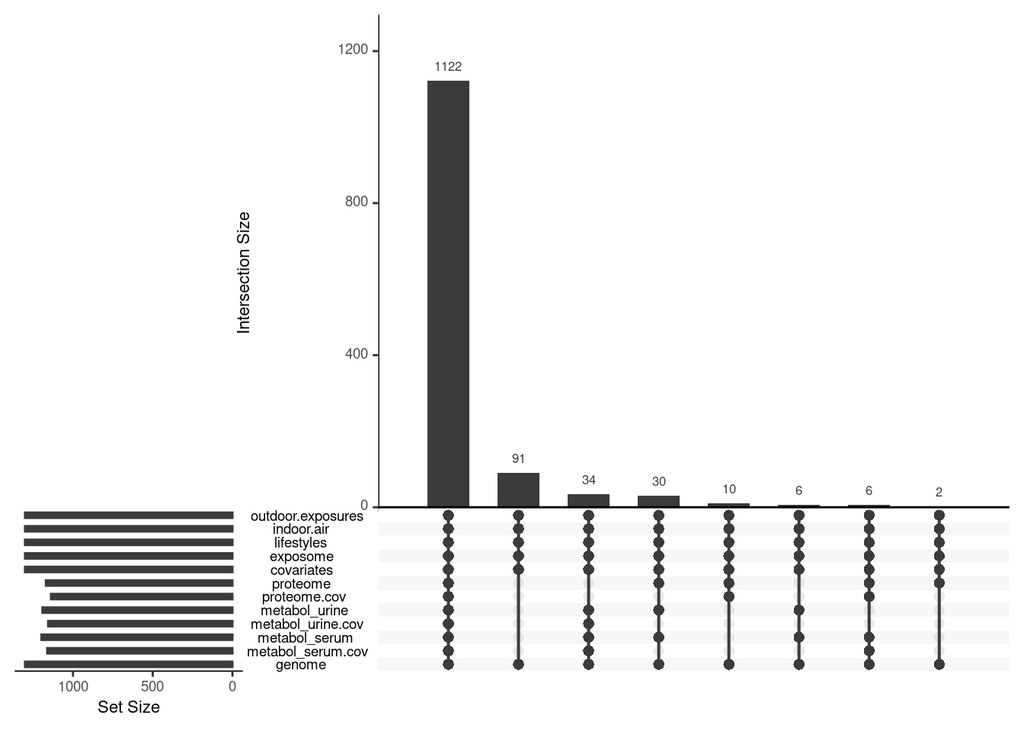

```r
upsetSamples(helix_ma, nintersects = 10)
```